# **Rraven: Connecting R and Raven Sound Analysis Software**

[Marcelo Araya-Salas, PhD](https://marceloarayasalas.weebly.com/)

“2021-04-20”

The `Rraven` package is designed to facilitate the exchange of data between R and [Raven sound analysis software](https://ravensoundsoftware.com) ([Cornell Lab of Ornithology](https://www.birds.cornell.edu/home)). [Raven](https://ravensoundsoftware.com) provides very powerful tools for the analysis of (animal) sounds. R can simplify the automatization of complex routines of analyses. Furthermore, R packages as warbleR, seewave and monitoR (among others) provide additional methods of analysis, working as a perfect complement for those found in [Raven](https://ravensoundsoftware.com). Hence, bridging these applications can largely expand the bioacoustician’s toolkit.

Currently, most analyses in [Raven](https://ravensoundsoftware.com) cannot be run in the background from a command terminal. Thus, most `Rraven` functions are design to simplify the exchange of data between the two programs, and in some cases, export files to [Raven](https://ravensoundsoftware.com) for further analysis. This vignette provides detailed examples for each function in `Rraven`, including both the R code as well as the additional steps in [Raven](https://ravensoundsoftware.com) required to fully accomplished the analyses. Raven Pro must be installed to be able to run some of the code. Note that the animations explaining these additional [Raven](https://ravensoundsoftware.com) steps are shown in more detail in the [github](https://github.com/maRce10/Rraven) version of this vignette, which can be downloaded as follows (saves the file “Rraven.github.html” in your current working directory):

```r
download.file(
  url = "https://raw.githubusercontent.com/maRce10/Rraven/master/gifs/Rraven.hitgub.html",
  destfile = "Rraven.github.html")
```

The downloaded file can be opened by any internet browser.

Before getting into the functions, the packages must be installed and loaded. I recommend using the latest developmental version, which is found in [github](https://github.com/maRce10/Rraven). To do so, you need the R package devtools (which of course should be installed!). Some warbleR functions and example data sets will be used, so warbleR should be installed as well:

```r
devtools::install_github("maRce10/warbleR")

devtools::install_github("maRce10/Rraven")

#from CRAN would be
#install.packages("warbleR")

#load packages
library(warbleR)
library(Rraven)
```

Let’s also use a temporary folder as the working directory in which to save all sound files and data files:

```r
setwd(tempdir())

#load example data
data(list = c("Phae.long1", "Phae.long2", "Phae.long3", "Phae.long4", "selec.table", "selection_files"))

#save sound files  in temporary directory
writeWave(Phae.long1, "Phae.long1.wav", extensible = FALSE)
writeWave(Phae.long2, "Phae.long2.wav", extensible = FALSE)
writeWave(Phae.long3, "Phae.long3.wav", extensible = FALSE)
writeWave(Phae.long4, "Phae.long4.wav", extensible = FALSE)

#save Raven selection tables in the temporary directory
out <- lapply(1:4, function(x)
writeLines(selection_files[[x]], con = names(selection_files)[x]))

#this is the temporary directory location (of course different each time is run)
getwd()
```

## Importing data from Raven

### *imp_raven*

```r
list.files(path = tempdir(), pattern = "\\.txt$")
```

```
[1] "LBH 1 selection table example.txt" "LBH 2 selection table example.txt" "LBH 3 selection table example.txt" "LBH 4 selection table example.txt"
```

This code shows how to import all the data contained in those files into R:

```r
 #providing the name of the column with the sound file names
rvn.dat <- imp_raven(all.data = TRUE, path = tempdir())

head(rvn.dat)
```

| Selection | View | Channel | Begin Time (s) | End Time (s) | Low Freq (Hz) | High Freq (Hz) | Begin File | channel | Begin Path | File Offset (s) | File Offset | selec.file |
| --- | --- | --- | --- | --- | --- | --- | --- | --- | --- | --- | --- | --- |
| 1 | Spectrogram 1 | 1 | 1.1693549 | 1.3423884 | 2220.105 | 8604.378 | Phae.long1.wav | 1 | /tmp/RtmpWpOeaR/Phae.long1.wav | 1.1693549 | NA | LBH 1 selection table example.txt |
| 2 | Spectrogram 1 | 1 | 2.1584085 | 2.3214565 | 2169.437 | 8807.053 | Phae.long1.wav | 1 | /tmp/RtmpWpOeaR/Phae.long1.wav | 2.1584085 | NA | LBH 1 selection table example.txt |
| 3 | Spectrogram 1 | 1 | 0.3433366 | 0.5182553 | 2218.294 | 8756.604 | Phae.long1.wav | 1 | /tmp/RtmpWpOeaR/Phae.long1.wav | 0.3433366 | NA | LBH 1 selection table example.txt |
| 1 | Spectrogram 1 | 1 | 0.1595983 | 0.2921692 | 2316.862 | 8822.316 | Phae.long2.wav | 1 | /tmp/RtmpWpOeaR/Phae.long2.wav | 0.1595983 | NA | LBH 2 selection table example.txt |
| 2 | Spectrogram 1 | 1 | 1.4570585 | 1.5832087 | 2284.006 | 8888.027 | Phae.long2.wav | 1 | /tmp/RtmpWpOeaR/Phae.long2.wav | 1.4570585 | NA | LBH 2 selection table example.txt |
| 1 | Spectrogram 1 | 1 | 0.6265520 | 0.7577715 | 3006.834 | 8822.316 | Phae.long3.wav | 1 | /tmp/RtmpWpOeaR/Phae.long3.wav | NA | 0.626552 | LBH 3 selection table example.txt |

Note that the ‘waveform’ view data has been removed. It can also be imported as follows (but note that the example selection tables have no waveform data):

```r
rvn.dat <- imp_raven(all.data = TRUE, waveform = TRUE,
                     path = tempdir())
```

[Raven](https://ravensoundsoftware.com) selections can also be imported in a ‘selection.table’ format so it can be directly input into warbleR functions. To do this you need to set `warbler.format = TRUE`:

```r
 #providing the name of the column with the sound file names
rvn.dat <- imp_raven(sound.file.col = "End.File",
                     warbler.format =  TRUE, path = tempdir())

head(rvn.dat)
```

| selec | Channel | start | end | bottom.freq | top.freq | sound.files | channel | selec.file |
| --- | --- | --- | --- | --- | --- | --- | --- | --- |
| 1 | 1 | 1.169355 | 1.342388 | 2.22011 | 8.60438 | Phae.long1.wav | 1 | LBH 1 selection table example.txt |
| 2 | 1 | 2.158408 | 2.321457 | 2.16944 | 8.80705 | Phae.long1.wav | 1 | LBH 1 selection table example.txt |
| 3 | 1 | 0.343337 | 0.518255 | 2.21829 | 8.75660 | Phae.long1.wav | 1 | LBH 1 selection table example.txt |
| 1 | 1 | 0.159598 | 0.292169 | 2.31686 | 8.82232 | Phae.long2.wav | 1 | LBH 2 selection table example.txt |
| 2 | 1 | 1.457058 | 1.583209 | 2.28401 | 8.88803 | Phae.long2.wav | 1 | LBH 2 selection table example.txt |
| 1 | 1 | 0.626552 | 0.757771 | 3.00683 | 8.82232 | Phae.long3.wav | 1 | LBH 3 selection table example.txt |

```r
# convert to class selection.table
rvn.dat.st <- selection_table(rvn.dat, path = tempdir())

sp <- spectro_analysis(X = rvn.dat, bp = "frange", wl = 150,
             pb = FALSE, ovlp = 90, path = tempdir())

head(sp)
```

```
checking selections (step 1 of 2):
all selections are OK
```

| sound.files | selec | duration | meanfreq | sd | freq.median | freq.Q25 | freq.Q75 | freq.IQR | time.median | time.Q25 | time.Q75 | time.IQR | skew | kurt | sp.ent | time.ent | entropy | sfm | meandom | mindom | maxdom | dfrange | modindx | startdom | enddom | dfslope | meanpeakf |
| --- | --- | --- | --- | --- | --- | --- | --- | --- | --- | --- | --- | --- | --- | --- | --- | --- | --- | --- | --- | --- | --- | --- | --- | --- | --- | --- | --- |
| Phae.long1.wav | 1 | 0.173033 | 5.98235 | 1.39969 | 6.33172 | 5.29658 | 6.86952 | 1.57294 | 0.076455 | 0.046568 | 0.117463 | 0.070895 | 1.99804 | 7.02156 | 0.943429 | 0.886904 | 0.836731 | 0.651002 | 6.49105 | 3.825 | 8.325 | 4.50 | 7.20000 | 6.975 | 7.575 | 3.46754 | 7.125 |
| Phae.long1.wav | 2 | 0.163048 | 5.99730 | 1.42293 | 6.21213 | 5.32875 | 6.88079 | 1.55205 | 0.076655 | 0.043903 | 0.115680 | 0.071777 | 1.91836 | 7.33432 | 0.946822 | 0.888565 | 0.841313 | 0.667865 | 6.71394 | 3.975 | 8.475 | 4.50 | 4.90000 | 6.825 | 7.275 | 2.75992 | 6.975 |
| Phae.long1.wav | 3 | 0.174919 | 6.02060 | 1.51554 | 6.42844 | 5.15281 | 6.98331 | 1.83050 | 0.090243 | 0.053452 | 0.127729 | 0.074277 | 2.49536 | 11.13912 | 0.945082 | 0.886654 | 0.837961 | 0.671589 | 6.53271 | 2.325 | 8.625 | 6.30 | 10.30952 | 2.925 | 7.275 | 24.86869 | 7.125 |
| Phae.long2.wav | 1 | 0.132571 | 6.39830 | 1.34041 | 6.59597 | 5.60732 | 7.38085 | 1.77353 | 0.076867 | 0.054300 | 0.103665 | 0.049364 | 1.56852 | 6.01639 | 0.942466 | 0.895480 | 0.843959 | 0.608618 | 6.48287 | 4.875 | 8.025 | 3.15 | 11.47619 | 4.875 | 6.225 | 10.18323 | 7.425 |
| Phae.long2.wav | 2 | 0.126150 | 6.31184 | 1.37004 | 6.60202 | 5.60983 | 7.21321 | 1.60338 | 0.076103 | 0.052849 | 0.097947 | 0.045098 | 2.46900 | 10.88435 | 0.935771 | 0.897677 | 0.840020 | 0.615104 | 6.17614 | 3.075 | 7.725 | 4.65 | 9.58065 | 5.625 | 5.775 | 1.18906 | 6.675 |
| Phae.long3.wav | 1 | 0.131220 | 6.61240 | 1.09312 | 6.67013 | 6.06721 | 7.34937 | 1.28215 | 0.063505 | 0.043043 | 0.089613 | 0.046571 | 1.77369 | 6.62602 | 0.930244 | 0.895888 | 0.833394 | 0.570215 | 6.75629 | 4.875 | 8.175 | 3.30 | 11.04546 | 5.475 | 8.025 | 19.43308 | 6.675 |

And this code creates song catalogs:

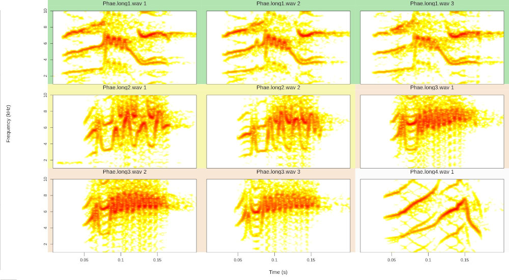

```r
# create a color palette
trc <- function(n) terrain.colors(n = n, alpha = 0.3)

# plot catalog
catalog(X = rvn.dat.st[1:9, ], flim = c(1, 10), nrow = 3, ncol = 3,
        same.time.scale = TRUE,  spec.mar = 1, box = FALSE,
        ovlp = 90, parallel = 1, mar = 0.01, wl = 200,
        pal = reverse.heat.colors, width = 20,
        labels = c("sound.files", "selec"), legend = 1,
        tag.pal = list(trc),  group.tag = "sound.files", path = tempdir())
```

This is just to mention a few analysis that can be implemented in warbleR.

`Rraven` also contains the function `imp_syrinx` to import selections from Syrinx sound analysis software (although this program is not been maintained any longer).

### *extract_ts*

The function extracts parameters encoded as time series in [Raven](https://ravensoundsoftware.com) selection tables. The resulting data frame can be directly input into functions for time series analysis of acoustic signals as in the warbleR function `freq_DTW`. The function needs an R data frame, so the data should have been previously imported using `imp_raven`. This example uses the `selection_file.ts` example data that comes with `Rraven`:

```r
#remove previous raven data files
unlink(list.files(pattern = "\\.txt$", path = tempdir()))

#save Raven selection table in the temporary directory
writeLines(selection_files[[5]], con = file.path(tempdir(),
                                        names(selection_files)[5]))

rvn.dat <- imp_raven(all.data = TRUE, path = tempdir())

# Peak freq contour dif length
fcts <- extract_ts(X = rvn.dat, ts.column = "Peak Freq Contour (Hz)")

head(fcts)
```

| sound.files | selec | PFC..1 | PFC..2 | PFC..3 | PFC..4 | PFC..5 | PFC..6 | PFC..7 | PFC..8 | PFC..9 | PFC..10 | PFC..11 | PFC..12 | PFC..13 | PFC..14 | PFC..15 | PFC..16 | PFC..17 | PFC..18 | PFC..19 | PFC..20 | PFC..21 | PFC..22 | PFC..23 | PFC..24 | PFC..25 | PFC..26 | PFC..27 | PFC..28 | … |
| --- | --- | --- | --- | --- | --- | --- | --- | --- | --- | --- | --- | --- | --- | --- | --- | --- | --- | --- | --- | --- | --- | --- | --- | --- | --- | --- | --- | --- | --- | --- |
| Phae.long1.wav | 1 | 6943.4 | 7119.1 | 7294.9 | 7294.9 | 7294.9 | 7382.8 | 7470.7 | 7646.5 | 5185.5 | 5273.4 | 5361.3 | 5449.2 | 5449.2 | 5537.1 | 5537.1 | 5712.9 | 6416.0 | 6591.8 | 6591.8 | 5976.6 | 6503.9 | 5712.9 | 6416.0 | 6240.2 | 5976.6 | 6328.1 | 5185.5 | 5009.8 | … |
| Phae.long1.wav | 2 | 6767.6 | 6943.4 | 7207.0 | 7207.0 | 7294.9 | 7382.8 | 7470.7 | 7558.6 | 7558.6 | 7646.5 | 5185.5 | 5361.3 | 5537.1 | 8261.7 | 8261.7 | 8349.6 | 5800.8 | 6152.3 | 6591.8 | 6679.7 | 5888.7 | 6416.0 | 5625.0 | 6152.3 | 5976.6 | 5976.6 | 5976.6 | 5273.4 | … |
| Phae.long1.wav | 3 | 6943.4 | 4746.1 | 7119.1 | 4834.0 | 7207.0 | 4921.9 | 4921.9 | 7558.6 | 7646.5 | 7734.4 | 7998.0 | 8085.9 | 5449.2 | 8085.9 | 8349.6 | 7998.0 | 8701.2 | 6503.9 | 6591.8 | 5800.8 | 6503.9 | 6503.9 | 6328.1 | 6416.0 | 5449.2 | 6152.3 | 5361.3 | 5273.4 | … |
| Phae.long2.wav | 4 | 5888.7 | 6503.9 | 4570.3 | 4834.0 | 5185.5 | 5537.1 | 5537.1 | 5800.8 | 6503.9 | 3779.3 | 6240.2 | 6328.1 | 6416.0 | 6591.8 | 5273.4 | 5712.9 | 4921.9 | 7382.8 | 6064.5 | 6767.6 | 7646.5 | 5800.8 | 7470.7 | 7294.9 | 7382.8 | 5537.1 | 6152.3 | 6416.0 | … |
| Phae.long2.wav | 5 | 4570.3 | 4746.1 | 4921.9 | 5097.7 | 5097.7 | 5185.5 | 5800.8 | 5712.9 | 5888.7 | 5976.6 | 6064.5 | 6064.5 | 4570.3 | 6855.5 | 6855.5 | 5976.6 | 6855.5 | 6679.7 | 6328.1 | 7646.5 | 5712.9 | 7207.0 | 6679.7 | 6591.8 | 6240.2 | 6855.5 | 6943.4 | 6416.0 | … |
| Phae.long3.wav | 6 | 4218.8 | 6240.2 | 6591.8 | 6679.7 | 7119.1 | 5009.8 | 5800.8 | 6240.2 | 6767.6 | 6416.0 | 6328.1 | 6328.1 | 6503.9 | 6679.7 | 6591.8 | 5537.1 | 6679.7 | 6679.7 | 6591.8 | 6943.4 | 5976.6 | 6591.8 | 7119.1 | 6767.6 | 7470.7 | 6416.0 | 7470.7 | 6591.8 | … |

Note that these sequences are not all of equal length (one has NAs at the end). `extract_ts` can also interpolate values so all time series have the same length:

```r
# Peak freq contour equal length
fcts <- extract_ts(X = rvn.dat, ts.column = "Peak Freq Contour (Hz)",  equal.length = TRUE)

#look at the last rows wit no NAs
head(fcts)
```

| sound.files | selec | PFC..1 | PFC..2 | PFC..3 | PFC..4 | PFC..5 | PFC..6 | PFC..7 | PFC..8 | PFC..9 | PFC..10 | PFC..11 | PFC..12 | PFC..13 | PFC..14 | PFC..15 | PFC..16 | PFC..17 | PFC..18 | PFC..19 | PFC..20 | PFC..21 | PFC..22 | PFC..23 | PFC..24 | PFC..25 | PFC..26 | PFC..27 | PFC..28 | … |
| --- | --- | --- | --- | --- | --- | --- | --- | --- | --- | --- | --- | --- | --- | --- | --- | --- | --- | --- | --- | --- | --- | --- | --- | --- | --- | --- | --- | --- | --- | --- |
| Phae.long1.wav | 1 | 6943.4 | 7246.40 | 7294.90 | 7397.96 | 7628.31 | 5240.06 | 5391.61 | 5455.26 | 5537.10 | 6076.57 | 6591.80 | 5997.81 | 5958.38 | 6343.26 | 6025.08 | 5343.10 | 4803.69 | 4197.51 | 7110.01 | 6788.82 | 6810.03 | 6979.75 | 7200.94 | 7207.00 | 6997.90 | 6646.35 | 7119.10 | 7158.50 | … |
| Phae.long1.wav | 2 | 6767.6 | 7107.01 | 7228.22 | 7370.68 | 7513.13 | 7567.69 | 5864.40 | 5421.92 | 8167.75 | 8313.23 | 5873.52 | 6516.02 | 6325.11 | 6361.45 | 5988.66 | 5976.60 | 5976.60 | 5273.40 | 4524.83 | 3958.11 | 7010.02 | 6855.50 | 6913.09 | 7143.35 | 7207.00 | 7207.00 | 7194.88 | 7119.10 | … |
| Phae.long1.wav | 3 | 6943.4 | 6464.48 | 5897.76 | 4921.90 | 7285.84 | 7701.06 | 8028.31 | 5631.04 | 8295.04 | 8361.72 | 6525.12 | 5828.08 | 6503.90 | 6364.47 | 5546.18 | 5470.40 | 5067.35 | 4373.31 | 3888.41 | 6810.03 | 6767.60 | 6961.57 | 7113.04 | 7203.97 | 7207.00 | 7049.39 | 7061.51 | 7079.70 | … |
| Phae.long2.wav | 4 | 5888.7 | 5903.82 | 4733.98 | 5161.26 | 5537.10 | 5682.59 | 6406.92 | 4203.59 | 6282.63 | 6397.81 | 6455.41 | 5455.26 | 5140.11 | 7337.34 | 6306.95 | 7343.43 | 5864.44 | 7422.20 | 7346.43 | 5728.03 | 6206.86 | 6143.26 | 7270.69 | 7219.12 | 6979.72 | 7525.28 | 7695.01 | 6009.94 | … |
| Phae.long2.wav | 5 | 4570.3 | 4788.53 | 5006.77 | 5097.70 | 5182.47 | 5782.61 | 5791.71 | 5949.32 | 6058.44 | 5806.88 | 5515.90 | 6855.50 | 6067.52 | 6831.25 | 6546.33 | 7146.42 | 5979.60 | 7152.45 | 6649.39 | 6385.69 | 6749.41 | 6907.03 | 6579.68 | 6749.41 | 6522.09 | 6455.40 | 7291.90 | 6137.20 | … |
| Phae.long3.wav | 6 | 4218.8 | 6361.44 | 6652.42 | 7046.37 | 5309.83 | 6118.99 | 6743.35 | 6379.63 | 6328.10 | 6522.09 | 6640.30 | 5755.31 | 6679.70 | 6637.27 | 6882.78 | 6082.67 | 6864.54 | 6816.08 | 7252.49 | 6997.90 | 6682.72 | 7785.85 | 7582.85 | 7091.82 | 7088.86 | 7143.41 | 7707.12 | 7337.33 | … |

And the length of the series can also be specified:

```r
# Peak freq contour equal length 10 measurements
fcts <- extract_ts(X = rvn.dat, ts.column = "Peak Freq Contour (Hz)",
equal.length = T, length.out = 10)

head(fcts)
```

| sound.files | selec | PFC..1 | PFC..2 | PFC..3 | PFC..4 | PFC..5 | PFC..6 | PFC..7 | PFC..8 | PFC..9 | PFC..10 |
| --- | --- | --- | --- | --- | --- | --- | --- | --- | --- | --- | --- |
| Phae.long1.wav | 1 | 6943.4 | 7431.63 | 5449.20 | 6533.20 | 6376.93 | 4736.33 | 6767.60 | 7207.00 | 7119.10 | 7119.1 |
| Phae.long1.wav | 2 | 6767.6 | 7402.33 | 5263.63 | 6650.40 | 6357.41 | 5898.47 | 4951.17 | 7041.01 | 7207.00 | 7207.0 |
| Phae.long1.wav | 3 | 6943.4 | 4921.90 | 7792.93 | 7236.33 | 6347.63 | 5000.01 | 6767.60 | 7040.97 | 7128.87 | 7119.1 |
| Phae.long2.wav | 4 | 5888.7 | 5263.63 | 5292.97 | 6533.20 | 7109.37 | 5986.34 | 5742.17 | 7363.27 | 7822.30 | 6152.3 |
| Phae.long2.wav | 5 | 4570.3 | 5097.70 | 5888.70 | 4570.30 | 6855.50 | 5712.90 | 6240.20 | 6943.40 | 7558.60 | 5537.1 |
| Phae.long3.wav | 6 | 4218.8 | 6416.00 | 6533.20 | 6679.70 | 6650.40 | 6943.33 | 7470.70 | 7617.20 | 7470.73 | 6855.5 |

The time series data frame can be directly input into the `freq_DTW` warbleR function to calculate [Dynamic Time Warping](https://en.wikipedia.org/wiki/Dynamic_time_warping) distances:

```r
freq_DTW(ts.df = fcts, path = tempdir())
```

|  | Phae.long1.wav-1 | Phae.long1.wav-2 | Phae.long1.wav-3 | Phae.long2.wav-4 | Phae.long2.wav-5 | Phae.long3.wav-6 | Phae.long3.wav-7 | Phae.long3.wav-8 | Phae.long4.wav-9 | Phae.long4.wav-10 | Phae.long4.wav-11 |
| --- | --- | --- | --- | --- | --- | --- | --- | --- | --- | --- | --- |
| Phae.long1.wav-1 | 0.00 | 2509.73 | 5702.99 | 9541.19 | 12411.93 | 9648.40 | 7207.00 | 7343.82 | 13740.28 | 11455.40 | 14970.64 |
| Phae.long1.wav-2 | 2509.73 | 0.00 | 5624.78 | 7334.11 | 12333.71 | 10058.78 | 7255.63 | 7734.49 | 14257.91 | 10908.22 | 15107.31 |
| Phae.long1.wav-3 | 5702.99 | 5624.78 | 0.00 | 10615.03 | 11620.86 | 11044.99 | 8046.64 | 7675.46 | 15077.77 | 13476.38 | 14696.92 |
| Phae.long2.wav-4 | 9541.19 | 7334.11 | 10615.03 | 0.00 | 7665.76 | 9111.46 | 7587.78 | 7109.27 | 11318.26 | 10683.49 | 11572.13 |
| Phae.long2.wav-5 | 12411.93 | 12333.71 | 11620.86 | 7665.76 | 0.00 | 8466.93 | 9160.36 | 8339.72 | 10839.78 | 13535.00 | 9902.21 |
| Phae.long3.wav-6 | 9648.40 | 10058.78 | 11044.99 | 9111.46 | 8466.93 | 0.00 | 6464.63 | 6425.53 | 16122.97 | 15234.57 | 14413.98 |
| Phae.long3.wav-7 | 7207.00 | 7255.63 | 8046.64 | 7587.78 | 9160.36 | 6464.63 | 0.00 | 4882.82 | 13144.40 | 11689.30 | 13095.31 |
| Phae.long3.wav-8 | 7343.82 | 7734.49 | 7675.46 | 7109.27 | 8339.72 | 6425.53 | 4882.82 | 0.00 | 13711.03 | 13144.48 | 13515.51 |
| Phae.long4.wav-9 | 13740.28 | 14257.91 | 15077.77 | 11318.26 | 10839.78 | 16122.97 | 13144.40 | 13711.03 | 0.00 | 10517.49 | 9424.16 |
| Phae.long4.wav-10 | 11455.40 | 10908.22 | 13476.38 | 10683.49 | 13535.00 | 15234.57 | 11689.30 | 13144.48 | 10517.49 | 0.00 | 9725.81 |
| Phae.long4.wav-11 | 14970.64 | 15107.31 | 14696.92 | 11572.13 | 9902.21 | 14413.98 | 13095.31 | 13515.51 | 9424.16 | 9725.81 | 0.00 |

### *relabel_colms*

This is a simple function to relabel columns so they match the selection table format used in warbleR:

```r
#to simplify the example select a subset of the columns
st1 <- rvn.dat[ ,1:7]

#check original column names
st1
```

[output not shown]

```r
# Relabel the basic columns required by warbleR
relabel_colms(st1)
```

[output not shown]

Additional columns can also be relabeled:

```r
# 2 additional column
relabel_colms(st1, extra.cols.name = "View",
              extra.cols.new.name = "Raven view")
```

| selec | Raven view | Channel | start | end | bottom.freq | top.freq |
| --- | --- | --- | --- | --- | --- | --- |
| 1 | Spectrogram 1 | 1 | 1.169 | 1.342033 | 2220.1 | 8604.4 |
| 2 | Spectrogram 1 | 1 | 2.158 | 2.321048 | 2169.4 | 8807.1 |
| 3 | Spectrogram 1 | 1 | 0.343 | 0.517919 | 2218.3 | 8756.6 |
| 4 | Spectrogram 1 | 1 | 0.160 | 0.292571 | 2316.9 | 8822.3 |
| 5 | Spectrogram 1 | 1 | 1.457 | 1.583150 | 2284.0 | 8888.0 |
| 6 | Spectrogram 1 | 1 | 0.627 | 0.758220 | 3006.8 | 8822.3 |
| 7 | Spectrogram 1 | 1 | 1.974 | 2.104179 | 2776.8 | 8888.0 |
| 8 | Spectrogram 1 | 1 | 0.123 | 0.254217 | 2316.9 | 9315.2 |
| 9 | Spectrogram 1 | 1 | 1.517 | 1.662425 | 2514.0 | 9216.6 |
| 10 | Spectrogram 1 | 1 | 2.933 | 3.077186 | 2579.7 | 10235.1 |
| 11 | Spectrogram 1 | 1 | 0.145 | 0.290099 | 2579.7 | 9742.3 |

### *imp_corr_mat*

The function imports the output of a batch correlation routine in [Raven](https://ravensoundsoftware.com). Both the correlation and lag matrices contained in the output ‘.txt’ file are read and both waveform and spectrogram (cross-correlation) correlations can be imported.

This example shows how to input the sound files into [Raven](https://ravensoundsoftware.com) and how to bring the results back to R. First, the selections need to be cut as single sound files for the [Raven](https://ravensoundsoftware.com) correlator to be able to read it. We can do this using the `cut_sels` function from warbleR:

```r
#create new folder to put cuts
dir.create(file.path(tempdir(), "cuts"))

# add a rowname column to be able to match cuts and selections
selec.table$rownames <- sprintf("%02d",1:nrow(selec.table))

# cut files
cut_sels(X = selec.table, mar = 0.05, path = tempdir(), dest.path =
           file.path(tempdir(), "cuts"),
         labels = c("rownames", "sound.files", "selec"), pb = FALSE)

#list cuts
list.files(path = file.path(tempdir(), "cuts"))
```

Every selection is in its own sound file (labeled as `paste("rownames", "sound.files", "selec")`). Now open [Raven](https://ravensoundsoftware.com) and run the batch correlator on the ‘cuts’ folder as follows:

[figure not shown]

And then import the output file into R:

```r
# Import output (change the name of the file if you used a different one)
xcorr.rav <- imp_corr_mat(file = "BatchCorrOutput.txt", path = tempdir())
```

The function returns a list containing the correlation matrix:

```r
xcorr.rav$correlation
```

|  | 01-Phae.long1-1.wav | 10-Phae.long4-2.wav | 11-Phae.long4-3.wav | 07-Phae.long3-2.wav | 05-Phae.long2-2.wav | 09-Phae.long4-1.wav | 04-Phae.long2-1.wav | 02-Phae.long1-2.wav | 06-Phae.long3-1.wav | 03-Phae.long1-3.wav | 08-Phae.long3-3.wav |
| --- | --- | --- | --- | --- | --- | --- | --- | --- | --- | --- | --- |
| 01-Phae.long1-1.wav | 1.000 | 0.216 | 0.184 | 0.285 | 0.443 | 0.195 | 0.145 | 0.613 | 0.360 | 0.812 | 0.236 |
| 10-Phae.long4-2.wav | 0.216 | 1.000 | 0.781 | 0.290 | 0.235 | 0.907 | 0.289 | 0.176 | 0.204 | 0.209 | 0.323 |
| 11-Phae.long4-3.wav | 0.184 | 0.781 | 1.000 | 0.279 | 0.186 | 0.804 | 0.274 | 0.127 | 0.189 | 0.185 | 0.393 |
| 07-Phae.long3-2.wav | 0.285 | 0.290 | 0.279 | 1.000 | 0.433 | 0.281 | 0.270 | 0.251 | 0.635 | 0.274 | 0.496 |
| 05-Phae.long2-2.wav | 0.443 | 0.235 | 0.186 | 0.433 | 1.000 | 0.197 | 0.243 | 0.449 | 0.397 | 0.363 | 0.304 |
| 09-Phae.long4-1.wav | 0.195 | 0.907 | 0.804 | 0.281 | 0.197 | 1.000 | 0.310 | 0.164 | 0.199 | 0.214 | 0.322 |
| 04-Phae.long2-1.wav | 0.145 | 0.289 | 0.274 | 0.270 | 0.243 | 0.310 | 1.000 | 0.151 | 0.302 | 0.182 | 0.256 |
| 02-Phae.long1-2.wav | 0.613 | 0.176 | 0.127 | 0.251 | 0.449 | 0.164 | 0.151 | 1.000 | 0.264 | 0.448 | 0.200 |
| 06-Phae.long3-1.wav | 0.360 | 0.204 | 0.189 | 0.635 | 0.397 | 0.199 | 0.302 | 0.264 | 1.000 | 0.318 | 0.377 |
| 03-Phae.long1-3.wav | 0.812 | 0.209 | 0.185 | 0.274 | 0.363 | 0.214 | 0.182 | 0.448 | 0.318 | 1.000 | 0.227 |
| 08-Phae.long3-3.wav | 0.236 | 0.323 | 0.393 | 0.496 | 0.304 | 0.322 | 0.256 | 0.200 | 0.377 | 0.227 | 1.000 |

and the time lag matrix:

```r
xcorr.rav$`lag (s)`
```

|  | 01-Phae.long1-1.wav | 10-Phae.long4-2.wav | 11-Phae.long4-3.wav | 07-Phae.long3-2.wav | 05-Phae.long2-2.wav | 09-Phae.long4-1.wav | 04-Phae.long2-1.wav | 02-Phae.long1-2.wav | 06-Phae.long3-1.wav | 03-Phae.long1-3.wav | 08-Phae.long3-3.wav |
| --- | --- | --- | --- | --- | --- | --- | --- | --- | --- | --- | --- |
| 01-Phae.long1-1.wav | 0.000 | 0.011 | 0.006 | 0.028 | 0.034 | 0.006 | 0.023 | 0.000 | 0.023 | -0.006 | 0.023 |
| 10-Phae.long4-2.wav | -0.011 | 0.000 | -0.006 | 0.040 | 0.023 | -0.006 | -0.028 | -0.017 | 0.040 | -0.017 | 0.057 |
| 11-Phae.long4-3.wav | -0.006 | 0.006 | 0.000 | 0.046 | 0.028 | 0.000 | -0.023 | -0.074 | 0.046 | -0.011 | 0.063 |
| 07-Phae.long3-2.wav | -0.028 | -0.040 | -0.046 | 0.000 | -0.011 | -0.046 | -0.023 | -0.034 | 0.000 | -0.028 | 0.017 |
| 05-Phae.long2-2.wav | -0.034 | -0.023 | -0.028 | 0.011 | 0.000 | -0.028 | 0.017 | -0.028 | 0.023 | -0.040 | 0.006 |
| 09-Phae.long4-1.wav | -0.006 | 0.006 | 0.000 | 0.046 | 0.028 | 0.000 | -0.023 | 0.034 | 0.046 | -0.011 | 0.063 |
| 04-Phae.long2-1.wav | -0.023 | 0.028 | 0.023 | 0.023 | -0.017 | 0.023 | 0.000 | -0.057 | 0.057 | -0.051 | 0.017 |
| 02-Phae.long1-2.wav | 0.000 | 0.017 | 0.074 | 0.034 | 0.028 | -0.034 | 0.057 | 0.000 | 0.040 | 0.000 | 0.023 |
| 06-Phae.long3-1.wav | -0.023 | -0.040 | -0.046 | 0.000 | -0.023 | -0.046 | -0.057 | -0.040 | 0.000 | -0.028 | 0.000 |
| 03-Phae.long1-3.wav | 0.006 | 0.017 | 0.011 | 0.028 | 0.040 | 0.011 | 0.051 | 0.000 | 0.028 | 0.000 | 0.023 |
| 08-Phae.long3-3.wav | -0.023 | -0.057 | -0.063 | -0.017 | -0.006 | -0.063 | -0.017 | -0.023 | 0.000 | -0.023 | 0.000 |

This output is ready for stats. For instance, the following code runs a mantel test between cross-correlation (converted to distances) and warbleR spectral parameter pairwise dissimilarities:

```r
#convert cross-corr to distance
xcorr.rvn <- 1- xcorr.rav$correlation

#sort matrix to match selection table
xcorr.rvn <- xcorr.rvn[order(rownames(xcorr.rvn)), order(colnames(xcorr.rvn))]

#convert it to distance matrix
xcorr.rvn <- as.dist(xcorr.rvn)

# measure acoustic parameters
sp.wrblR <- specan(selec.table, bp = c(1, 11), wl = 150,
                   pb = FALSE, path = tempdir())

#convert them to distance matrix
dist.sp.wrblR <- dist(sp.wrblR)
vegan::mantel(xcorr.rvn, dist.sp.wrblR)
```

```
Mantel statistic based on Pearson's product-moment correlation

Call:
vegan::mantel(xdis = xcorr.rvn, ydis = dist.sp.wrblR)

Mantel statistic r: 0.259
      Significance: 0.013

Upper quantiles of permutations (null model):
  90%   95% 97.5%   99%
0.142 0.180 0.216 0.270
Permutation: free
Number of permutations: 999
```

There is actually a good match between the two methods!

## Exporting R data to Raven

### *exp_raven*

*exp_raven* saves a selection table in ‘.txt’ format that can be directly opened in Raven. No objects are returned into the R environment. The following code exports a data table from a single sound file:

```r
# Select data for a single sound file
st1 <- selec.table[selec.table$sound.files == "Phae.long1.wav", ]

# Export data of a single sound file
exp_raven(st1, file.name = "Phaethornis 1", khz.to.hz = TRUE, path = tempdir())
```

If the path to the sound file is provided, the functions exports a ‘sound selection table’ which can be directly open by [Raven](https://ravensoundsoftware.com) (and which will also open the associated sound file):

```r
# Select data for a single sound file
st1 <- selec.table[selec.table$sound.files == "Phae.long1.wav",]

# Export data of a single sound file
exp_raven(st1, file.name = "Phaethornis 1", khz.to.hz = TRUE,
          sound.file.path = tempdir(), path = tempdir())
```

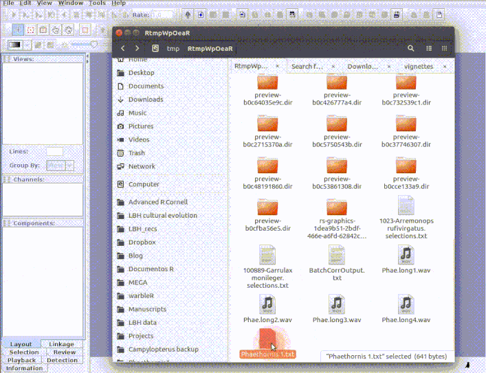

This is useful to add new selections or even new measurements:

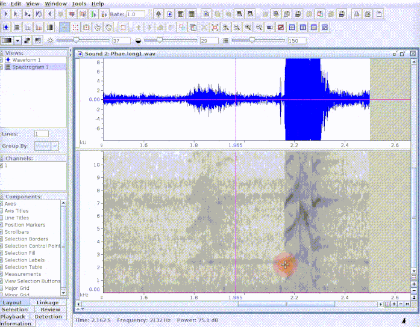

If several sound files are available, users can either export them as a single selection file or as multiple selection files (one for each sound file). This example creates a multiple sound file selection:

```r
exp_raven(X = selec.table, file.name = "Phaethornis multiple sound files",
          sound.file.path = tempdir(), single.file = TRUE, path = tempdir())
```

These type of tables can be opened as a multiple file display in [Raven](https://ravensoundsoftware.com).

## Running Raven from R

### *run_raven*

The function opens multiple sound files simultaneously in [Raven](https://ravensoundsoftware.com). When the analysis is finished (and the [Raven](https://ravensoundsoftware.com) window is closed) the data can be automatically imported back into R using the ‘import’ argument. Note that [Raven](https://ravensoundsoftware.com), unlike R, can also handle files in ‘mp3’, ‘flac’ and ‘aif’ format .

```r
# here replace with the path where Raven is install in your computer
raven.path <- "PATH_TO_RAVEN_DIRECTORY_HERE"

# run function
run_raven(raven.path = raven.path, sound.files = c("Phae.long1.wav", "Phae.long2.wav", "Phae.long3.wav", "Phae.long4.wav"),
          import = TRUE, all.data = TRUE, path = tempdir())
```

[figure not shown]

See `imp_raven` above for more details on additional settings when importing selections.

### *raven_batch_detec*

As the name suggests, *raven_batch_detec* runs [Raven](https://ravensoundsoftware.com) detector on multiple sound files (sequentially). Batch detection in [Raven](https://ravensoundsoftware.com) can also take files in ‘mp3’, ‘flac’ and ‘aif’ format (although this could not be further analyzed in R!).

This is example runs the detector on one of the example sound files that comes by default with [Raven](https://ravensoundsoftware.com):

```r
detec.res <- raven_batch_detec(raven.path = raven.path,
                               sound.files = "BlackCappedVireo.aif",
                               path = file.path(raven.path, "Examples"))
```

[figure not shown]

Please report any bugs [here](https://github.com/maRce10/Rraven/issues). The `Rraven` package should be cited as follows:

Araya-Salas, M. (2017), *Rraven: connecting R and Raven bioacoustic software*. R package version 1.0.0.